# HalefCaetano_GroupHistogram

Halef Caetano

1/13/2024

# Assignment Overview

This lab is preconfigured to include all dependencies (libraries, packages, and datasets) you’ll need to complete your work in RStudio. You can practice, run test cases, and work on assignments directly from your browser, and your work will be stored throughout the span of the course. To get started, head to the “Files” tab in RStudio where you’ll find any starter files needed to complete this activity. You’ll be able to access a copy of these assignment instructions both in this file (Instructions.pdf) in your lab and in the document attached to the Step 1: Grouped Histogram in R item.

## The basic steps should be included in this lab:

1. Load the required packages in R.
2. You’ll want to set your working directory to where you place your dataset. If you’re not sure what your current working directory is, you can use getwd() in your RStudio Console. Please note: Use “/” instead of “" in the path.
3. Please use the data provided to conduct a “Grouped Histogram” based on the step mentioned below. Load and inspect the dataset.
4. Break the variable “CrimeRate” into three groups based on the range and create a new variable “RangeGroup”. You can use case_then() function. Three groups:
- CrimeRate < 250 ~“CrimeRate < 250”
- CrimeRate >= 250 CrimeRate <= 500 ~ “250 <= CrimeRate <= 500”,
- CrimeRate >500 ~“CrimeRate > 500”)
5. Create two color vectors. The first color vector is obtained from colorspace::diverge_hcl() and the second color vector is formed by colors of “green”, “blue” and “red”.
6. Plot a histogram of the variable “CrimeRate” and fill with the variable “Year” using the first color vector.
7. Plot a histogram of the variable “CrimeRate” and fill with the variable “RangeGroup” using the second color vector.
8. Please show all the code in code chunks (set echo=TRUE).

```r
knitr::opts_chunk$set(echo = TRUE)

library(ggplot2)
library(tidyverse)
library(colorspace) # library so I can use diverge_hcl
library(readr)
Sampledata2 <- read_csv("Sampledata2.csv") # reading the data
```

```
## ──────────────────────────────────────────────────────── Delimiter: "," chr
## (1): State dbl (2): Year, CrimeRate lgl (2): ...4, ...5
```

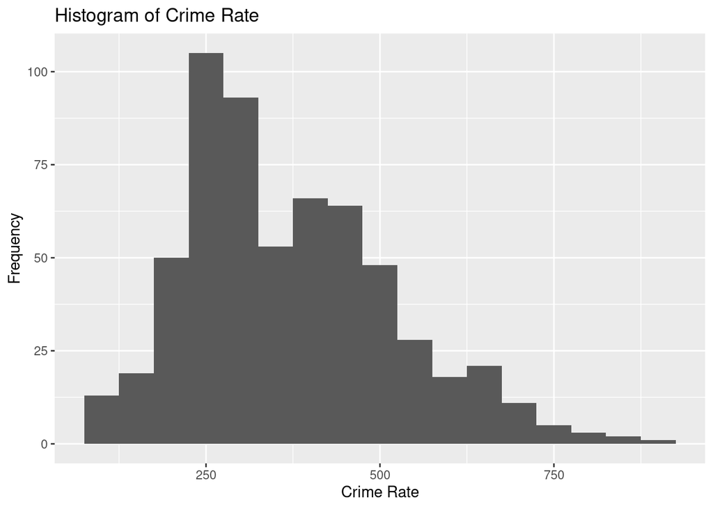

```r
Sampledata2 <- Sampledata2 %>% mutate(RangeGroup = case_when(CrimeRate < 250 ~ "CrimeRate < 250", CrimeRate >= 250 & CrimeRate <= 500 ~ "250 <= CrimeRate <= 500", CrimeRate > 500 ~ "CrimeRate > 500")) # creating three different groups
color1 <- diverge_hcl(20, palette = "Blue-Red") # creating the first color vector
color2 <- c("green", "blue", "red") # creating the second color vector
ggplot(Sampledata2, aes(x = CrimeRate, fill = Year)) + geom_histogram(binwidth = 50) + scale_fill_manual(values = color1) +labs(title = "Histogram of Crime Rate", x = "Crime Rate", y = "Frequency") # histogram of the variable “CrimeRate” and fill with the variable “Year” using the first color vector
```

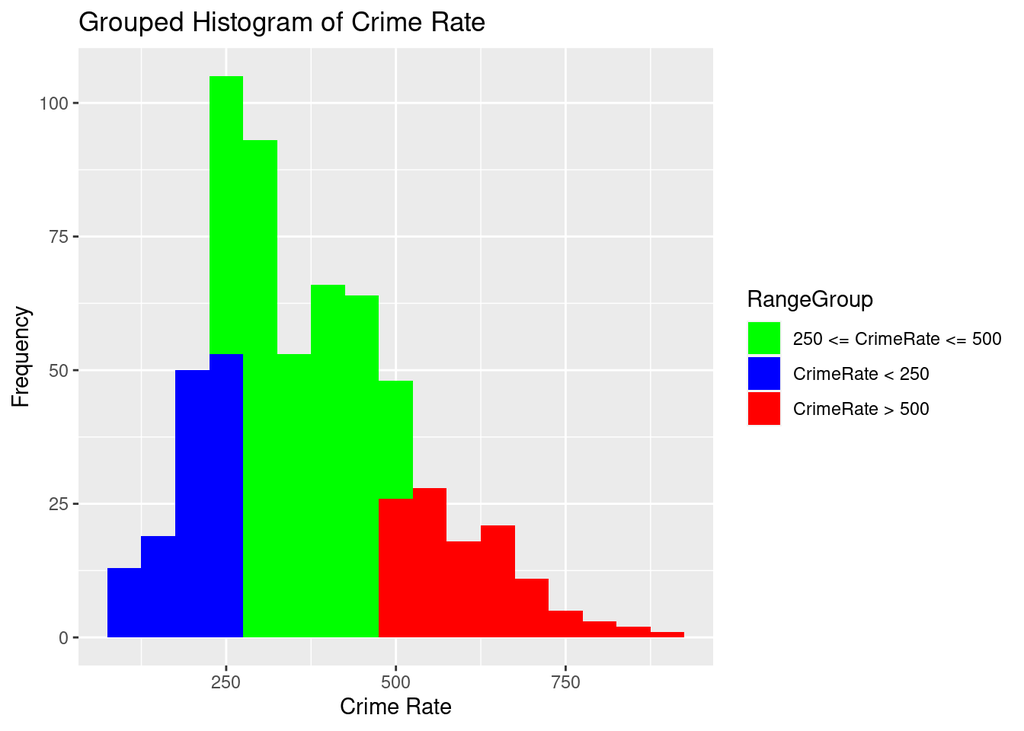

```r
ggplot(Sampledata2, aes(x = CrimeRate, fill = RangeGroup)) + geom_histogram(binwidth = 50) + scale_fill_manual(values = color2) + labs(title = "Grouped Histogram of Crime Rate", x = "Crime Rate", y = "Frequency") # histogram of the variable “CrimeRate” and fill with the variable “RangeGroup” using the second color vector
```